# Model Selection

## Projects

## Model Selection

## The Problem of Model Selection

[figure not shown]

A given data set can conceivably have been generated from uncountably many models. Identifying the true model is like finding a piece of hay in a haystack. Said another way, the model space is massive and the criterion for what constitutes the "best" model is ill-defined.

## The Problem of Model Selection

**Best strategy**: Use domain knowledge to constrain the model space and/or build models that help you answer specific scientific questions.

**Another common strategy:**

1. Pick a criterion for "best".
2. Decide how to explore the model space.
3. Select "best" model in search area.

**Tread Carefully!!!** The second strategy can lead to myopic analysis, overconfidence, and wrong-headed conclusions.

## What do we mean by "best"?

While we'd like to find the "true" model, in practice we just hope we're doing a good job at:

1. Prediction
2. Description

## Synthetic example

How smooth should our model be?

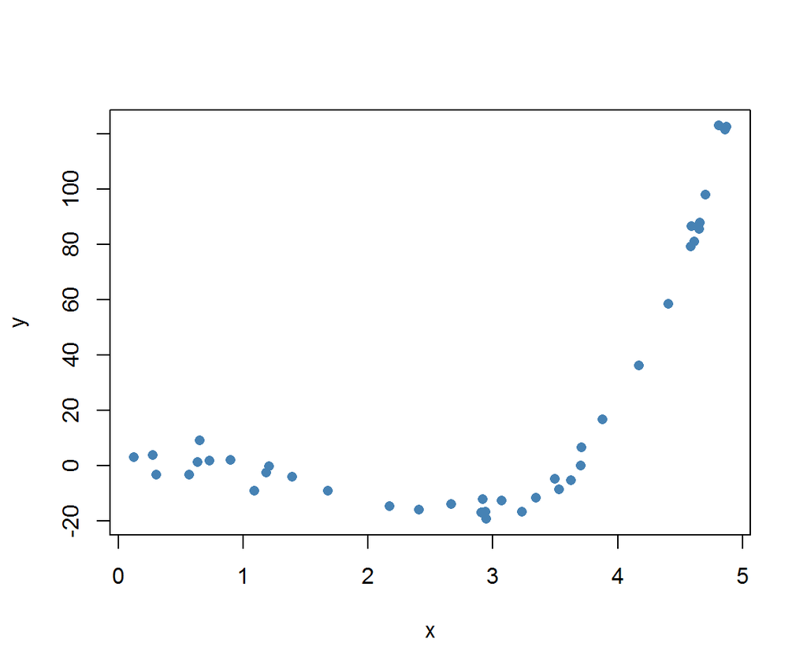

## Four candidates

```r
m1 <- lm(y ~ x)
m2 <- lm(y ~ x + I(x^2))
m3 <- lm(y ~ x + I(x^2) + I(x^3))
m4 <- lm(y ~ x + I(x^2) + I(x^3) + I(x^4))
```

## Four candidates

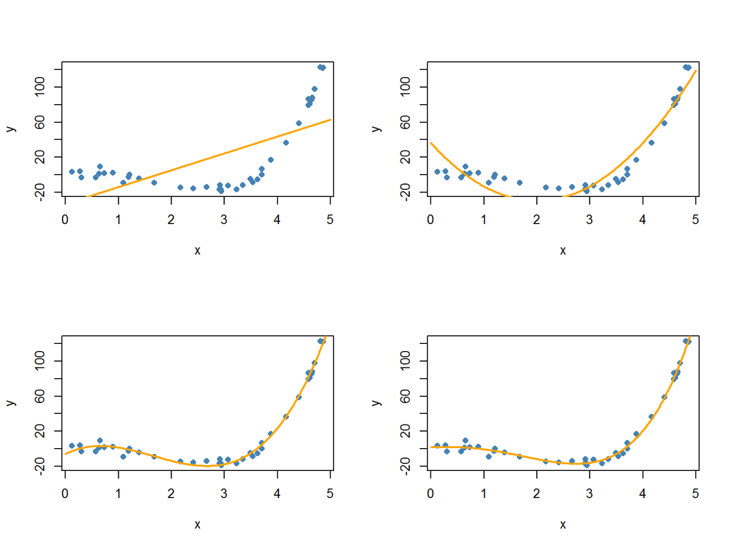

## Likelihood

**Def:** the joint probability (actually: density) of all of the data given a particular model. If our \(Y\)s are independent of each other given the \(X\), then:

\[ P(Y_. | X_.) = P(y_1 | x_1) P(y_2 | x_2) \ldots P(y_n | x_n) \]

```r
L1 <- prod(dnorm(m1$res, mean = 0, sd = summary(m1)$sigma))
```

## Comparing Likelihoods

```r
L1 <- prod(dnorm(m1$res, mean = 0, sd = summary(m1)$sigma))
L2 <- prod(dnorm(m2$res, mean = 0, sd = summary(m2)$sigma))
L3 <- prod(dnorm(m3$res, mean = 0, sd = summary(m3)$sigma))
L4 <- prod(dnorm(m4$res, mean = 0, sd = summary(m4)$sigma))
c(L1, L2, L3, L4)
```

```
## [1] 1.845701e-86 1.252416e-69 2.682451e-49 6.055980e-47
```

The observed data is most probable under the model with a quartic term. So that's the best model, right?

## The BEST model!

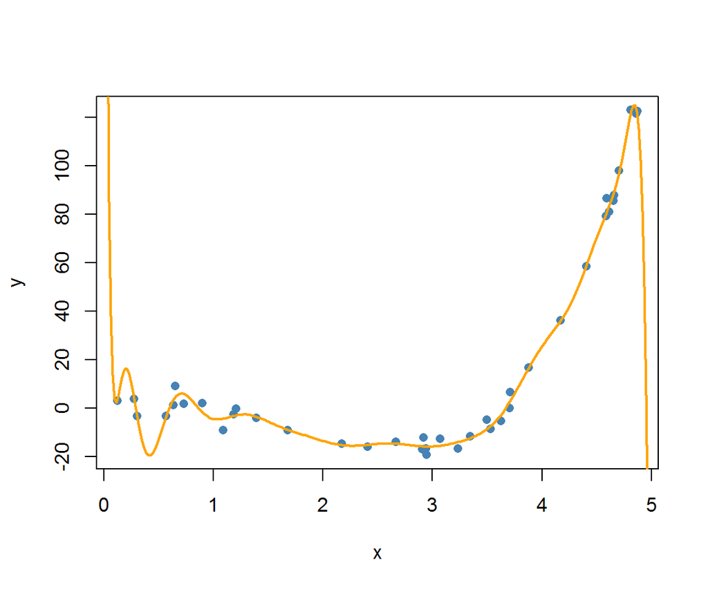

## The BEST model!

```r
mBEST <- lm(y ~ poly(x, 20))
LBEST <- prod(dnorm(mBEST$res, mean = 0, sd = summary(mBEST)$sigma))
c(L1, L2, L3, L4, LBEST)
```

```
## [1] 1.845701e-86 1.252416e-69 2.682451e-49 6.055980e-47 1.052673e-42
```

But surely that's not the best model…

## Four Criteria

1. \(R^2_{adj}\)
2. \(AIC\)
3. \(AIC_C\)
4. \(BIC\)

There are many others…

## \(R^2_{adj}\)

A measure of explanatory power of model:

\[ R^2 = SSreg/SST= 1 - RSS/SST \]

But like likelihood, it only goes up with added predictors, therefore we add a penalty.

\[ R^2_{adj} = 1 - \frac{RSS/(n - (p + 1))}{SST/(n - 1)} \]

Nonetheless, choosing the model that has the highest \(R^2_{adj}\) can lead to *overfitting*.

## \(AIC\)

*Akaike Information Criterion*: `AIC`, a balance of goodness of fit and complexity using information theory.

\[ AIC = 2[-log(\textrm{likelihood of model}) + (p + 2)] \]

which can be simplified to,

\[ AIC = n log(\frac{RSS}{n}) + 2p \]

Smaller = better. Tends to overfit in small sample sizes.

## \(AIC_C\)

*AIC Corrected*: a bias-corrected version for use on small sample sizes.

\[ AIC_C = AIC + \frac{2(p + 2)(p + 3)}{n - (p + 1)} \]

## \(BIC\)

*Bayesian Information Criterion*: `BIC`, for all but the very smallest data sets, takes a heavier penalty for complexity.

\[ BIC = -2 log(\textrm{likelihood of model}) + (p + 2) log(n) \]

## Criteria compared

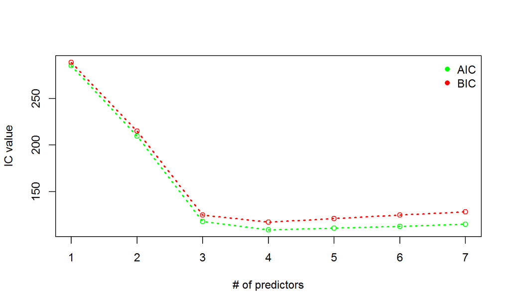